# Northern Three Spatial Analyses (Derive a Rough Bohle Population and Area)

- Show All Code
- Hide All Code
- View Source

Author

Adam Shand

Published

June 10, 2024

**R Version**

For R session info at the time of rendering this script see Section 7.

# 1 Introduction

This script is designed to (roughly) calculate the population and area of the Bohle sub basin as we define it, as a proportion of the Townsville LGA. Note that our area is spatially different from how the Bohle might be determined form a normal population perspective (e.g. via suburb, or SA2 boundary). We define the Bohle based on the water dynamics of the area.

# 2 Script Set Up

This script requires multiple core spatial packages, all packages are loaded below.

```r
#load packages
library(tidyverse)
library(glue)
library(here)
library(readxl)
library(sf)
library(tmap)
```

Then we also need to set up key variables for the script, as well as the output location.

```r
#set project crs
proj_crs <- params$project_crs

#create a file path to help with saving outputs
save_outputs <- here("outputs/dt_maps_bohle-population/")
save_data <- here("data/dt_maps/population/")

#bring the path to life
dir.create(save_outputs)
dir.create(save_data)

#turn off s2 geometry
sf_use_s2(FALSE)
```

# 3 Load Data

Now the script is set up we need to load in all of the required datasets. We will need:

- The Northern Three region file (to define our Bohle boundary)
- The SA1 polygons
- The excel file that gives (rough) estimates of population per SA1 polygon
- The Townsville LGA area

```r
#load in the n3 region
n3_region <- st_read(here("data/n3_prep_region-builder/n3_region.gpkg"))
#filter to just the Bohle
bohle <- n3_region |>
  filter(sub_basin_or_sub_zone == "Bohle River") |>
  group_by(sub_basin_or_sub_zone) |>
  summarise(geom = st_union(geom))

#filter for the marine boundary
marine <- n3_region |>
  filter(environment == "Marine") |>
  st_union()

#load the SA1 data
sa1 <- st_read(glue("{save_data}/SA1_2021_AUST_GDA2020.shp"))
#load SA1 excel data
sa1_pop <- read_excel(glue("{save_data}/estimated_sa1_population.xlsx"))

#load the LGA data
lga <- st_read(glue("{save_data}/../lga.gpkg"))
#load LGA excel data
lga_pop <- read_csv(glue("{save_data}/estimated_lga_population.csv"))

#read in qld outlines data from the gisaimsr package, filter for land and islands, update crs
qld <- get(data("gbr_feat", package = "gisaimsr")) |> filter(FEAT_NAME %in% c("Mainland", "Island")) |>
  st_transform(proj_crs)
```

# 4 Edit Data

Then we assign each of the populations to the polygons

```r
#----------
# SA1
#----------

#make sure columns are the same type
sa1 <- sa1 |> mutate(SA1_CODE21 = as.character(SA1_CODE21))
sa1_pop <- sa1_pop |> mutate(SA1 = as.character(SA1))

#combine data
sa1_combined <- left_join(sa1, sa1_pop, join_by("SA1_CODE21" == "SA1"))

#filter spatially
bohle_pop <- st_filter(sa1_combined, bohle, .predicates = st_intersects)

#select rows of interest
bohle_pop <- bohle_pop |>
  select(SA1_CODE21, `2023p`)

#----------
# LGA
#----------

#make sure columns have cells that will match
lga <- lga |>
  mutate(ABBREV_NAME = str_to_title(ABBREV_NAME))

lga_pop <- lga_pop |> rename("ABBREV_NAME" = "...1") |>
   mutate(ABBREV_NAME = str_replace(ABBREV_NAME, "\\s*\\(\\w\\)$", ""))

#combine data
lga_combined <- left_join(lga, lga_pop)

#select row of interest
tsv_pop <- lga_combined |>
  filter(LGA == "Townsville City")
```

# 5 Calculate Results

Then we can easily calculate the total population within the Bohle (total TSV is already done), then work out the proportions of population and area.

```r
#----------
# Population
#----------

#calculate the population in the area
bohle_total_pop <- sum(bohle_pop$`2023p`)

#select the pop of townsville
tsv_total_pop <- tsv_pop$`2023p`

#calculate pop proportion
bohle_pop_proportion <- scales::percent(round(bohle_total_pop/tsv_total_pop, 2))

#----------
# Area
#----------

#get area of each location
bohle_area <- st_area(bohle)
units(bohle_area) <- units::make_units(km^2)
bohle_area <- round(units::drop_units(bohle_area), 2)

#however, tsv lga needs its marine section cut off first as thats not really a good comparison otherwise
tsv_area_shp <- st_difference(tsv_pop, marine)
tsv_area <- st_area(tsv_area_shp)
units(tsv_area) <- units::make_units(km^2)
tsv_area <- round(units::drop_units(tsv_area), 2)

#calculate area proportion
bohle_area_proportion <- scales::percent(round(bohle_area/tsv_area, 2))

#save the results
results <- tibble(location = c("Townsville", "Bohle", "Proportion"),
                  area = c(tsv_area, bohle_area, bohle_area_proportion),
                  population = c(tsv_total_pop, bohle_total_pop, bohle_pop_proportion))

write_csv(results, glue("{save_outputs}/bohle_statistics.csv"))
```

# 6 Map Example

Lastly we will create a map that demonstrates the size difference of the two.

```r
#load in custom mapping function
source(here("functions/report_base_map.R"))

#create the initial base map using the custom function. hand the largest outline to the supplied_sf variable
report_base_map(supplied_sf = tsv_area_shp, regi = "Dry Tropics", strm_ord = 2, colour = F)
```

```
[1] "The variables 'n3_region' and 'n3_watercourse' were assigned to the global environment to enhance function speed within loops."
[1] "The variables 'base_inset' and 'base_vp' were assigned to the global environment to use for an inset map."
[1] "The base map has been assigned to the global environment with the name 'base_map'."
```

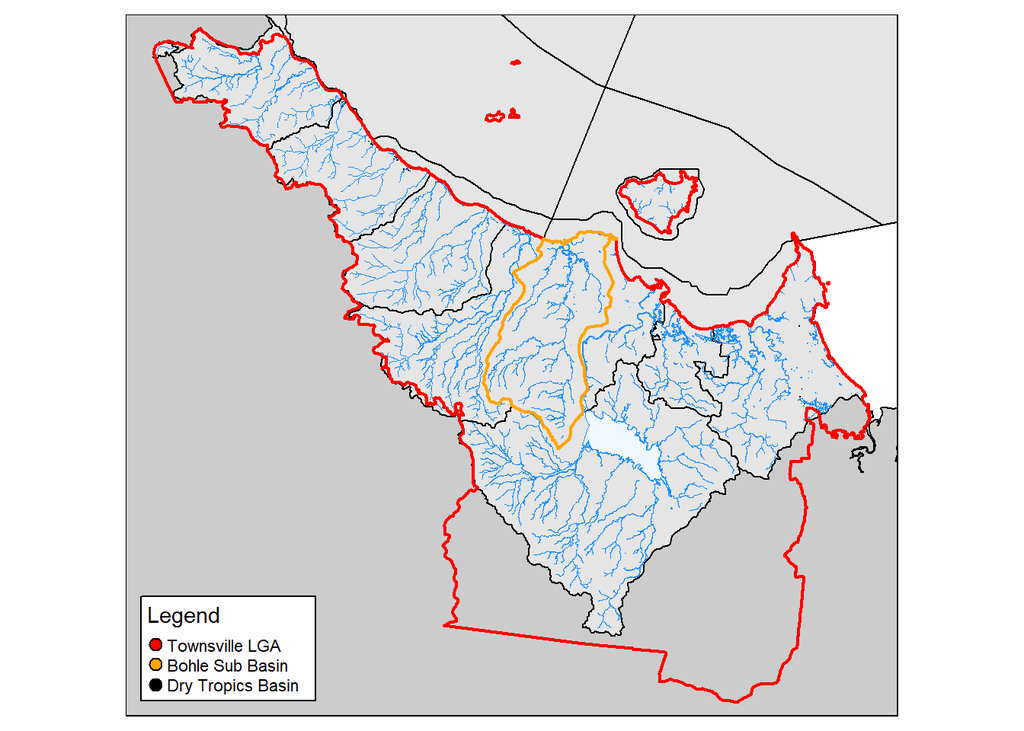

```r
#add extra features to the base map
final_map <- base_map +
  tm_shape(tsv_area_shp, is.master = T) +
  tm_borders(col = "red", lwd = 2) +
  tm_shape(bohle) +
  tm_borders(col = "orange", lwd = 2) +
  tm_add_legend(type = "symbol", col = c("red", "orange", "black"),
                labels = c("Townsville LGA", "Bohle Sub Basin", "Dry Tropics Basin"),
                title = "Legend")

#save
tmap_save(final_map, glue("{save_outputs}/bohle_map.png"))

#and visualise
final_map
```

# 7 Session Info

Below is the session info at the time of rendering this script. Of greatest importance is to note the R version, and the “other attached packages” as these are the most significant drivers of success/failure. It is also good to check the “attached base packages” and “loaded via a namespace” packages as well. To check your session info use `sessionInfo()`.

[session information not shown]